# Puget Lowland Sword Fern Mortality Study

## Getting started

The latest version of the field data is stored on my website. read that file into a the standard R data structure the data.frame (a table).

```r
f <- "https://pshannon.net/fernSurvey2025/uwObs.tsv"
tbl <- read.table(f, sep="\t", header=TRUE, comment="", quote="")
```

examine the data, make sure it is what you expect.  
first, how many rows, how many columns?

```r
dim(tbl)
```

```
[1] 41 23
```

what are the column names?

```r
colnames(tbl)
```

```
 [1] "observer"            "siteName"            "lat"                 "lon"
 [5] "date"                "time"                "elevation"           "area"
 [9] "width"               "length"              "slope"               "aspect"
[13] "canopyType"          "canopyDensity"       "healthyFernCount"    "sickOrDeadFernCount"
[17] "dead.Class.1"        "dead.Class.2"        "dead.Class.3"        "dead.Class.4"
[21] "notes"               "photos"              "mortality"
```

how many sites have no dead ferns? R’s subset command is very useful!

```r
nrow(subset(tbl, sickOrDeadFernCount == 0))
```

```
[1] 9
```

now examine the distribution of that variable across the whole dataset.  
first, get a “five-number summary”:

- min
- 1st quartile
- median
- third quartile
- max

```r
fivenum(tbl$sickOrDeadFernCount)
```

```
[1]  0  5  9 17 73
```

now visually:

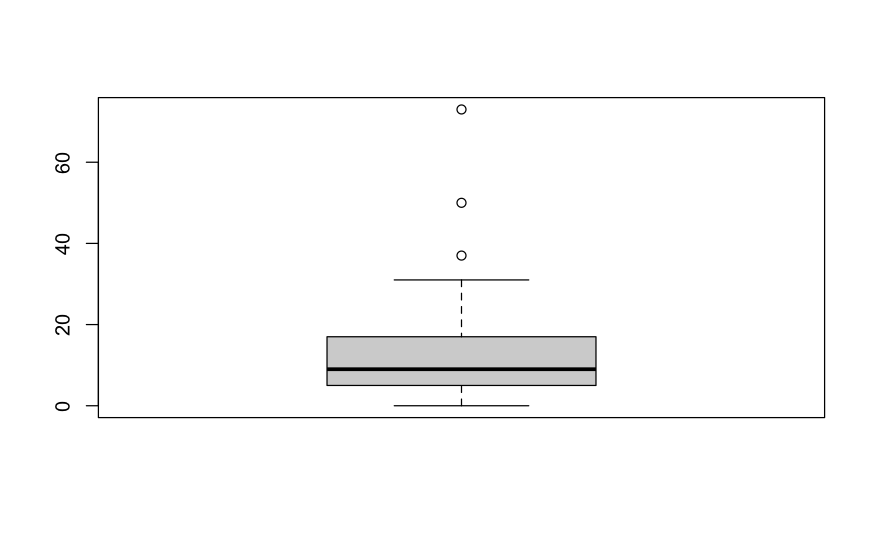

```r
boxplot(tbl$sickOrDeadFernCount)
```

and as a histogram:

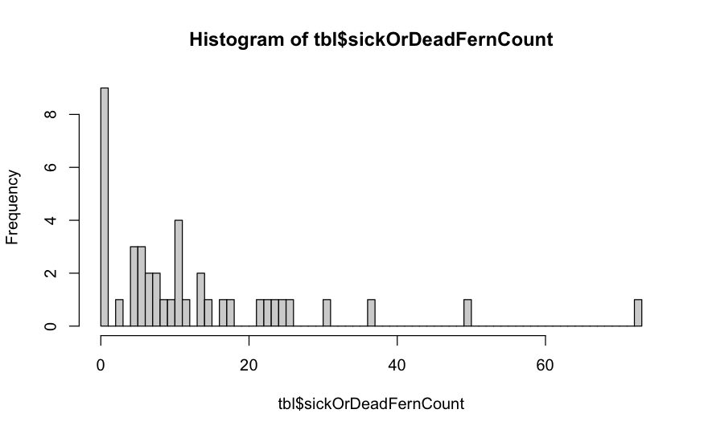

```r
hist(tbl$sickOrDeadFernCount, breaks=73)
```

add a column to the table: “fernCount” to simplify later calculations.

```r
fernCount <- tbl$healthyFernCount +  tbl$sickOrDeadFernCount
tbl$fernCount <- fernCount
```

add another column: ‘northerly’ a number between 0 and 180. This calculation had me confused for a while…

The field data records an aspect of 0 for due north: we want it to be 180

aspect 180 is due south: we want 0

all sites with aspect close to due north (e.g., 10, 350) should be close to 180 (e.g, both of them 170).

northeast and northwest, each being 45 degrees off of north, become 135

The first step is to extract the site aspect values, from the table, as a simple vector of integers:

```r
tmp <- tbl$aspect
length(tmp)
```

```
[1] 41
```

now find which of those vectors slope to the west, which to the east

```r
west <- which(tmp>180)
east <- which(tmp <= 180)
length(west)
```

```
[1] 18
```

```r
length(east)
```

```
[1] 23
```

now adjust the values so that the follow the scheme described above, where all range between 180 (due north) and 0 (due south)

```r
tmp[west] <- tmp[west] - 180
tmp[east] <- 180 - tmp[east]
```

assign these values as a new column in the table, so we can use it in subsequent calculations, for instance, to see if fern mortality associates with northerly slope

```r
tbl$northerly <- tmp
```

sanity check these steps. how is “northerly” distributed?

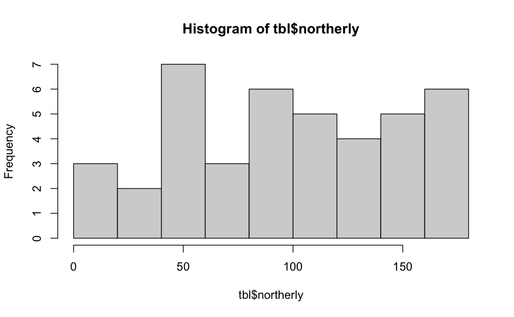

```r
hist(tbl$northerly)
```